# Matplot by IQRA Learnings

# Noor Mohammed Sadiq Shaik

### These are the questions rises when we think about the data visualization

- **What is Data Visualization..?**
- **Why should we Visualize the data**
- **What are the different libraries in python to visualize the data**
1. **Data Visualization** Data visualization is a general term that describes any effort to help people understand the significance of data by placing it in a visual context. Patterns, trends and correlations that might go undetected in text-based data can be exposed and recognized easier with data visualization software.
2. **Data visualization** can also Identify areas that need attention or improvement. Clarify which factors influence customer behavior. Help you understand which products to place where. Predict sales volumes.
3. Useful Python Data Visualization Libraries for Any Discipline
   1. **matplotlib**. Despite being over a decade old, it's still the most widely used library ...
   2. **Seaborn**. Seaborn harnesses the power of matplotlib to create beautiful charts in a few lines ...
   3. **ggplot**. For instance, you can start with axes, then add points, then a line, a trendline, etc.

### In this tutorial we will work on MatPlotLib

#### Why we Choose Matplot..?

- **Provides a Module called Pyplot**
- **Simple Functions used for visualization**
- **supports easy wise variety of graphics**
- **easy integration with Pandas & NumPy**
- **Provides an Object Oriented API** ### How to import it -----> import matplotlib.pyplot as (Variable_Name)

```python
import matplotlib.pyplot as plt
```

## Types of plots we are going to discuss in matplotlib

1. **Line Plot**
2. **Bar Graph Plot**
3. **Scatter Plot**
4. **Histogram Plot**
5. **Pi Plot**
6. **Doughnut Plot**
7. **Box Plot**
8. **Violin Plot**
9. **Area Plot** And Many More...

## Drawing Line Plots

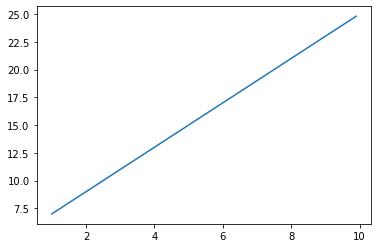

```python
## Line Plotting

from matplotlib import pyplot as plt
import numpy as np

x=np.arange(1,10,0.1)
y=2*x+5

plt.plot(x,y)
plt.show()
```

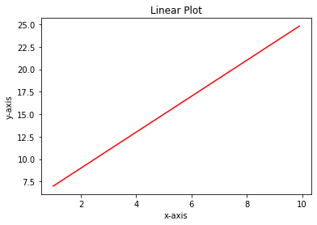

```python
x=np.arange(1,10,0.1)
y=2*x+5
plt.plot(x,y,color='r')
plt.title('Linear Plot')
plt.xlabel('x-axis')
plt.ylabel('y-axis')
plt.show()
```

### Drawing Sub-Line Plots

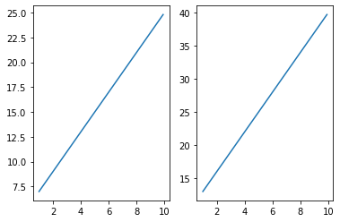

```python
x=np.arange(1,10,0.1)
y=2*x+5
z=3*x+10

plt.subplot(1,2,1)
plt.plot(x,y)


plt.subplot(1,2,2)
plt.plot(x,z)
plt.show()
```

## Bar Graph Plotting

```python
# Bar Plotting

from matplotlib import pyplot as plt
import numpy as np

fruits = {'Banana':30,'Orange':50,'Mango':70,'Apple':100}
names = list(fruits.keys())
price = list(fruits.values())
names,price
```

```
(['Banana', 'Orange', 'Mango', 'Apple'], [30, 50, 70, 100])
```

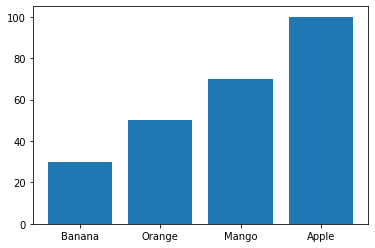

```python
plt.bar(names,price)
plt.show()
```

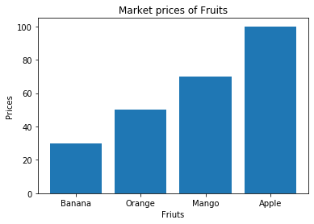

```python
plt.bar(names,price)
plt.title('Market prices of Fruits')    # Adds Title For Plot
plt.xlabel('Friuts')                    # Labels the graph axis
plt.ylabel('Prices')
plt.show()
```

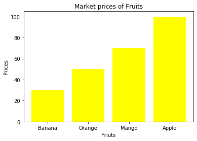

```python
plt.bar(names,price,color='yellow')    # Uses to Change the color of the plot
plt.title('Market prices of Fruits')
plt.xlabel('Friuts')
plt.ylabel('Prices')
plt.show()
```

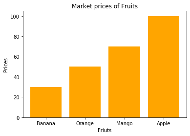

```python
plt.bar(names,price,color='orange')
plt.title('Market prices of Fruits')
plt.xlabel('Friuts')
plt.ylabel('Prices')
plt.show()
```

## Horizontal Bar Plotting

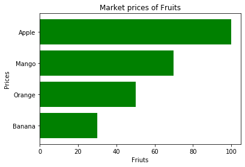

```python
# horizontal Plotting
plt.barh(names,price,color='green')
plt.title('Market prices of Fruits')
plt.xlabel('Friuts')
plt.ylabel('Prices')
plt.show()
```

## Scatter Plotting

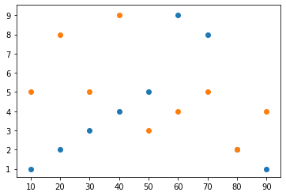

```python
# Scatter plot

x = [10,20,30,40,50,60,70,80,90]
a = [1,2,3,4,5,9,8,2,1]
b = [5,8,5,9,3,4,5,2,4]
plt.scatter(x,a)
plt.scatter(x,b)
plt.show()
```

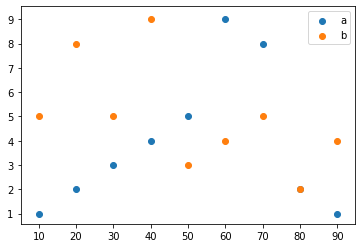

```python
x = [10,20,30,40,50,60,70,80,90]
a = [1,2,3,4,5,9,8,2,1]
b = [5,8,5,9,3,4,5,2,4]
plt.scatter(x,a)
plt.scatter(x,b)
plt.legend(['a','b'])     # Adds the label on the grapg with representation
plt.show()
```

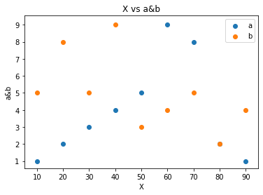

```python
x = [10,20,30,40,50,60,70,80,90]
a = [1,2,3,4,5,9,8,2,1]
b = [5,8,5,9,3,4,5,2,4]
plt.scatter(x,a)
plt.scatter(x,b)
plt.legend(['a','b'])
plt.title('X vs a&b')
plt.xlabel('X')
plt.ylabel('a&b')
plt.show()
```

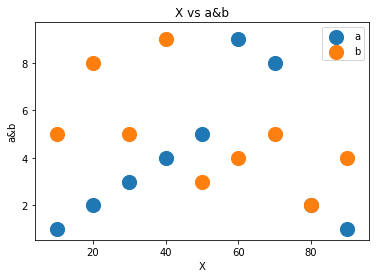

```python
x = [10,20,30,40,50,60,70,80,90]
a = [1,2,3,4,5,9,8,2,1]
b = [5,8,5,9,3,4,5,2,4]
plt.scatter(x,a,s=200)    # Changing the size of the bubble
plt.scatter(x,b,s=200)
plt.legend(['a','b'])
plt.title('X vs a&b')
plt.xlabel('X')
plt.ylabel('a&b')
plt.show()
```

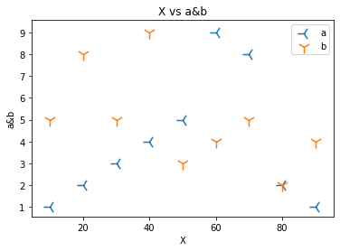

```python
x = [10,20,30,40,50,60,70,80,90]
a = [1,2,3,4,5,9,8,2,1]
b = [5,8,5,9,3,4,5,2,4]
plt.scatter(x,a,s=200,marker='3')      # Changing the Shape of the Bubble
plt.scatter(x,b,s=200,marker='1')
plt.legend(['a','b'])
plt.title('X vs a&b')
plt.xlabel('X')
plt.ylabel('a&b')
plt.show()
```

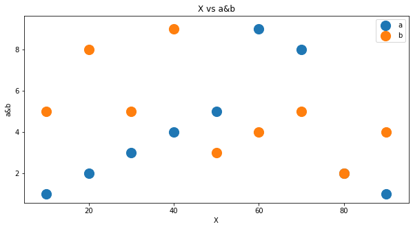

```python
x = [10,20,30,40,50,60,70,80,90]
a = [1,2,3,4,5,9,8,2,1]
b = [5,8,5,9,3,4,5,2,4]

plt.figure(figsize=(10,5))    # Setting Figure Size as required
plt.scatter(x,a,s=200)
plt.scatter(x,b,s=200)
plt.legend(['a','b'])
plt.title('X vs a&b')
plt.xlabel('X')
plt.ylabel('a&b')
plt.show()
```

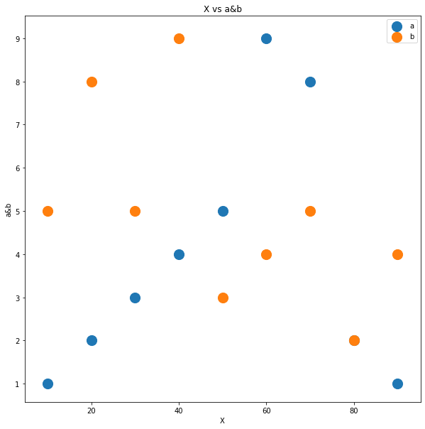

```python
x = [10,20,30,40,50,60,70,80,90]
a = [1,2,3,4,5,9,8,2,1]
b = [5,8,5,9,3,4,5,2,4]

plt.figure(figsize=(10,10))
plt.scatter(x,a,s=200)
plt.scatter(x,b,s=200)
plt.legend(['a','b'])
plt.title('X vs a&b')
plt.xlabel('X')
plt.ylabel('a&b')
plt.show()
```

## Histogram Plotting

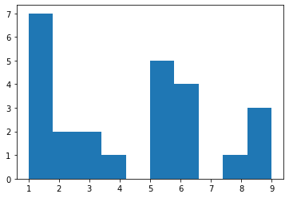

```python
# Histogram Plot

from matplotlib import pyplot as plt
import numpy as np
import pandas as pd

data = [1,1,5,2,6,8,1,2,3,6,9,4,5,3,1,1,5,5,9,9,6,6,1,5,1]

plt.hist(data)
plt.show()
```

## Importing an CSV file

```python
iris = pd.read_csv(r'C:\Users\Welcome\Desktop\Data Analysis\Data Science\Plotting\iris.csv')

iris.head()
```

|  | sepal.length | sepal.width | petal.length | petal.width | variety |
| --- | --- | --- | --- | --- | --- |
| 0 | 5.1 | 3.5 | 1.4 | 0.2 | Setosa |
| 1 | 4.9 | 3.0 | 1.4 | 0.2 | Setosa |
| 2 | 4.7 | 3.2 | 1.3 | 0.2 | Setosa |
| 3 | 4.6 | 3.1 | 1.5 | 0.2 | Setosa |
| 4 | 5.0 | 3.6 | 1.4 | 0.2 | Setosa |

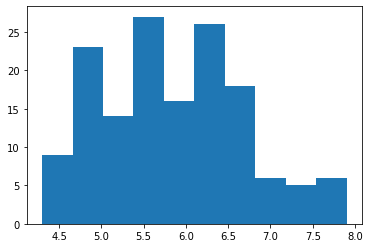

```python
plt.hist(iris['sepal.length'])
plt.show()
```

### Changing the Color of the plot

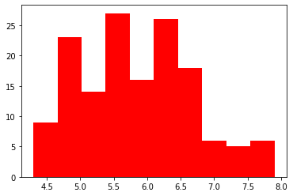

```python
plt.hist(iris['sepal.length'],color='red')
plt.show()
```

### Changing the width of the bar in histogram

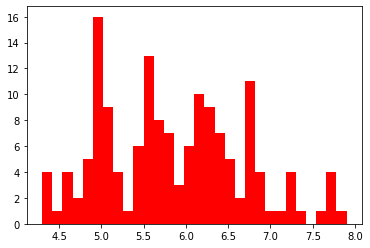

```python
plt.hist(iris['sepal.length'],color='red',bins=30)
plt.show()
```

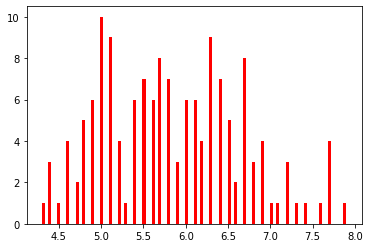

```python
plt.hist(iris['sepal.length'],color='red',bins=100)
plt.show()
```

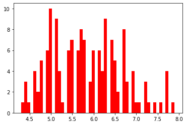

```python
plt.hist(iris['sepal.length'],color='red',bins=50)
plt.show()
```

## Pi Charts

```python
# Pi Charts

from matplotlib import pyplot as plt
import numpy as np
import pandas as pd
```

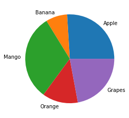

```python
fruits = ['Apple','Banana','Mango','Orange','Grapes']
price = [100,30,120,50,85]

plt.pie(price,labels=fruits)
plt.show()
```

### Dividing the Persentage to the pi plot

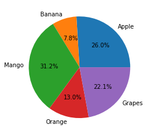

```python
fruits = ['Apple','Banana','Mango','Orange','Grapes']
price = [100,30,120,50,85]

plt.pie(price,labels=fruits,autopct='%0.1f%%')       # Uses for representating the persentage of the space occupied
plt.show()
```

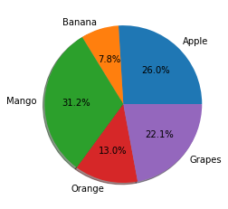

```python
fruits = ['Apple','Banana','Mango','Orange','Grapes']
price = [100,30,120,50,85]

plt.pie(price,labels=fruits,autopct='%0.1f%%',shadow=True)    # Shows The Shadow
plt.show()
```

### Slicing the Pi Chart using its indexing values based on '0' & '1'

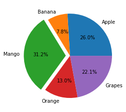

```python
fruits = ['Apple','Banana','Mango','Orange','Grapes']
price = [100,30,120,50,85]

plt.pie(price,labels=fruits,autopct='%0.1f%%',explode=(0,0,0.1,0,0))      # Slicing the required area from the pi plot
plt.show()
```

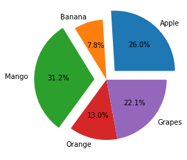

```python
fruits = ['Apple','Banana','Mango','Orange','Grapes']
price = [100,30,120,50,85]

plt.pie(price,labels=fruits,autopct='%0.1f%%',explode=(0.2,0,0.2,0,0))
plt.show()
```

### Keeping Our required colors in pi chart

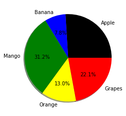

```python
fruits = ['Apple','Banana','Mango','Orange','Grapes']
price = [100,30,120,50,85]

plt.pie(price,labels=fruits,autopct='%0.1f%%',shadow=True,colors=['black','blue','green','yellow','red'])
plt.show()
```

## Doughnut Plot

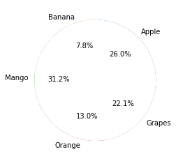

```python
#Doughnut_Charts

from matplotlib import pyplot as plt
import numpy as np
import pandas as pd

fruits = ['Apple','Banana','Mango','Orange','Grapes']
price = [100,30,120,50,85]

pie1 = plt.pie(price,labels=fruits,autopct='%0.1f%%')
pie2 = plt.pie([5],colors='w')
plt.show()
```

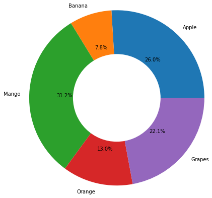

```python
fruits = ['Apple','Banana','Mango','Orange','Grapes']
price = [100,30,120,50,85]

pie1 = plt.pie(price,labels=fruits,autopct='%0.1f%%',radius=2)
pie2 = plt.pie([5],colors='w',radius=1)
plt.show()
```

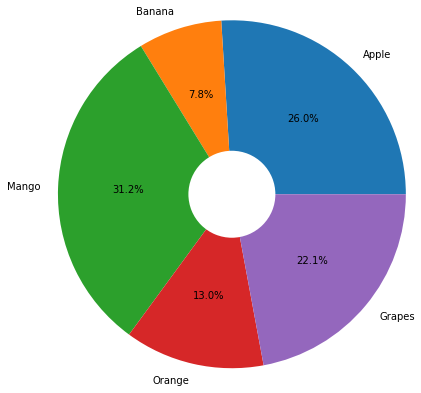

```python
fruits = ['Apple','Banana','Mango','Orange','Grapes']
price = [100,30,120,50,85]

pie1 = plt.pie(price,labels=fruits,autopct='%0.1f%%',radius=2)
pie2 = plt.pie([5],colors='w',radius=0.5)
plt.show()
```

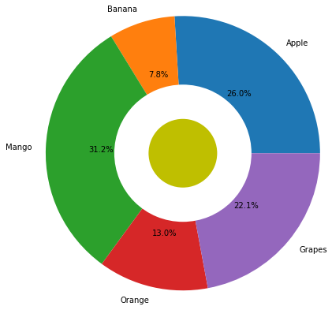

```python
fruits = ['Apple','Banana','Mango','Orange','Grapes']
price = [100,30,120,50,85]

pie1 = plt.pie(price,labels=fruits,autopct='%0.1f%%',radius=2)
pie2 = plt.pie([5],colors='w',radius=1)
pie3 = plt.pie([5],colors='y',radius=0.5)
plt.show()
```

## Box Plot

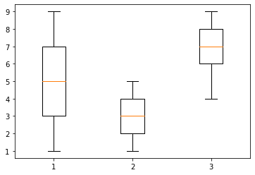

```python
# Box Plot

from matplotlib import pyplot as plt
import numpy as np
import pandas as pd

x = [1,2,3,4,5,6,7,8,9]
y = [1,2,3,4,5,4,3,2,1]
z = [6,7,8,9,8,7,6,5,4]

data = list([x,y,z])

plt.boxplot(data)
plt.show()
```

## Violin Plot

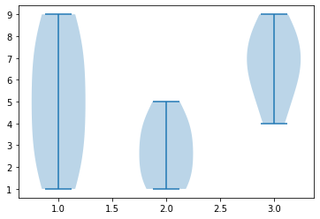

```python
x = [1,2,3,4,5,6,7,8,9]
y = [1,2,3,4,5,4,3,2,1]
z = [6,7,8,9,8,7,6,5,4]

data = list([x,y,z])

#plt.boxplot(data)
plt.violinplot(data)
plt.show()
```

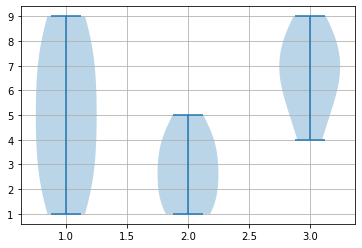

```python
x = [1,2,3,4,5,6,7,8,9]
y = [1,2,3,4,5,4,3,2,1]
z = [6,7,8,9,8,7,6,5,4]

data = list([x,y,z])

plt.violinplot(data)
plt.grid(True)            # Adding Grids to plot
plt.show()
```

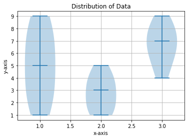

```python
x = [1,2,3,4,5,6,7,8,9]
y = [1,2,3,4,5,4,3,2,1]
z = [6,7,8,9,8,7,6,5,4]

data = list([x,y,z])

plt.violinplot(data,showmedians=True)     # Function for showing the Medians Values of the graph
plt.title('Distribution of Data')
plt.xlabel('x-axis')
plt.ylabel('y-axis')
plt.grid(True)
plt.show()
```

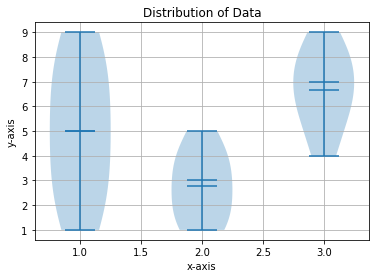

```python
x = [1,2,3,4,5,6,7,8,9]
y = [1,2,3,4,5,4,3,2,1]
z = [6,7,8,9,8,7,6,5,4]

data = list([x,y,z])

plt.violinplot(data,showmedians=True,showmeans=True)     # Function for showing the Mean Values of the graph
plt.title('Distribution of Data')
plt.xlabel('x-axis')
plt.ylabel('y-axis')
plt.grid(True)
plt.show()
```

## Area Plotting

```python
# Area plot

from matplotlib import pyplot as plt
import numpy as np
import pandas as pd

X = [10,20,30,40,50,60,70,80,90]
Y = [1,2,5,6,3,4,7,5,9]
```

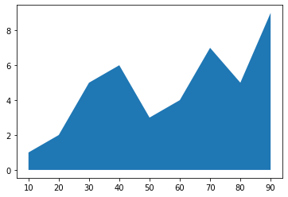

```python
X = [10,20,30,40,50,60,70,80,90]
Y = [1,2,5,6,3,4,7,5,9]

plt.stackplot(X,Y)
plt.show()
```

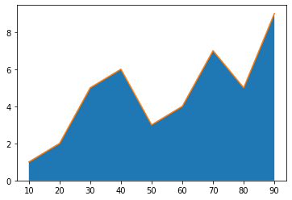

```python
x = [10,20,30,40,50,60,70,80,90]
y = [1,2,5,6,3,4,7,5,9]

plt.stackplot(x,y)
plt.plot(x,y)
plt.show()
```

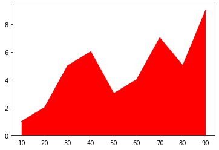

```python
x = [10,20,30,40,50,60,70,80,90]
y = [1,2,5,6,3,4,7,5,9]

plt.stackplot(x,y,colors='r')       # Changing color of the plot
plt.plot(x,y)
plt.show()
```

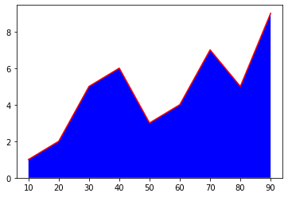

```python
x = [10,20,30,40,50,60,70,80,90]
y = [1,2,5,6,3,4,7,5,9]

plt.stackplot(x,y,colors='blue')
plt.plot(x,y,color='r')               # Used for analyse the data in the peak values
plt.show()
```

## if you face any difficulties kindly reach to my e-mail

## shaiknoormohammedsadiq@gmail.com